# Problem 1

**Write a program to print diamond star patterns. Take input N from the user where n is the number of rows as well as the column in star. N is always odd. Below is an example for N =7 [1 Mark]**

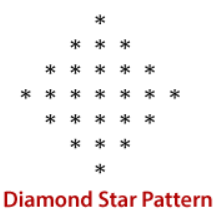

```python
def printDiamond(n):
    if n==1:
        print('*')
    elif (n>2):
        # Print Upper half of the Diamond
        for i in range((n//2),-1,-1):
            # White Spaces before first star in the row
            print(" "*(2*i),end="")
            # Print Stars
            print("* "*(2*((n//2)-i)+1))
        # Print lower half of the diamond
        for i in range(1,(n//2)+1):
            # White Spaces before first star in the row
            print(" "*(2*i),end="")
            # Print Stars
            print("* "*(n-(2*(i))))
```

```python
printDiamond(7)
```

[output not shown]

```python
printDiamond(11)
```

[output not shown]

# Problem 2

Given four different points in space, write a program to find whether these points can form a square or not. [2 Marks]

**Example 1:**  
Input:  
x1 = 20, y1 = 10, x2 = 10, y2 = 20,  
x3 = 20, y3 = 20, x4 = 10, y4 = 10  
Output: Yes  
Explanation:  
The points (20,10), (10,20), (20,20), (10,10) forms a square.

**Example 2:**  
Input:  
x1 = 2, y1 = 1, x2 = 10, y2 = 20,  
x3 = 5, y3 = 6, x4 = 10, y4 = 10  
Output: No  
Explanation:  
The points (2,1), (10,20), (5,6),  
(10,10) doesn't form a square.

## Approach

if $p_1=(x_1,y_1)$, $p_2=(x_2,y_2)$,$p_3=(x_2,y_2)$, and $p_4=(x_4,y_4)$ are 4 points and they form a square, then the distance of a point to itself will be $0$, distance to two other points will be constant say, $a$, and distance to the remaining point should be $\sqrt{2}a$. This should be true for each of the point $p_i$, $i=1,2,3,4$.  
So maintain 4 lists, $p_idist$ where we store the distance from $p_i$ to each of the 4 points. If you sort all the 4 lists, and the points form a square, then all the lists should be equal to $[0,a,a,\sqrt{2}a]$ for some constant $a$. We just check if this is true for all the lists or not, if it is true for all the list, then the points form a valid square else they don't.

```python
def ValidSquare(p1,p2,p3,p4):
    p1_dist=sorted([0,((p1[0]-p2[0])**2)+((p1[1]-p2[1])**2),((p1[0]-p3[0])**2)+((p1[1]-p3[1])**2),((p1[0]-p4[0])**2)+((p1[1]-p4[1])**2)])
    p2_dist=sorted([((p2[0]-p1[0])**2)+((p2[1]-p1[1])**2),0,((p2[0]-p3[0])**2)+((p2[1]-p3[1])**2),((p2[0]-p4[0])**2)+((p2[1]-p4[1])**2)])
    p3_dist=sorted([((p3[0]-p1[0])**2)+((p3[1]-p1[1])**2),((p3[0]-p2[0])**2)+((p3[1]-p2[1])**2),0,((p3[0]-p4[0])**2)+((p3[1]-p4[1])**2)])
    p4_dist=sorted([((p4[0]-p1[0])**2)+((p4[1]-p1[1])**2),((p4[0]-p2[0])**2)+((p4[1]-p2[1])**2),((p4[0]-p3[0])**2)+((p4[1]-p3[1])**2),0])


    dist_mat=[p1_dist,p2_dist,p3_dist,p4_dist]

    if (dist_mat[0][1]==dist_mat[1][1]) and (dist_mat[0][1]==dist_mat[2][1]) and (dist_mat[0][1]==dist_mat[3][1]):
        sum=0
        for i in range(4):
            if (dist_mat[i][1]==dist_mat[i][2]) and (2*dist_mat[i][1]==dist_mat[i][3]) and (dist_mat[i][1]!=0):
                sum+=1
        if sum==4:
            print("Yes")
        else:
            print("No")
    else:
        print("No")
```

```python
p1,p2,p3,p4=[20,10],[10,20],[20,20],[10,10]
ValidSquare(p1,p2,p3,p4)
```

```
Yes
```

```python
p1,p2,p3,p4=[2,1],[10,20],[5,6],[10,10]
ValidSquare(p1,p2,p3,p4)
```

```
No
```

## Optimal Approach

https://leetcode.com/problems/valid-square/editorial/